# DNSC 6279 Section 11 Spring 2020 Homework 3

Ziwei Li

*Remark.* This homework aims to help you further understand the model selection techniques in linear model. Credits for **Theoretical Part** and **Computational Part** are in total 100 pt. For **Computational Part** , please complete your answer in the **RMarkdown** file and summit your printed PDF homework created by it.

## Computational Part

**Hint.** Before starting your work, carefully read Textbook Chapter 6.5-6.7 (Lab 1-3). Mimic the related analyses you learn from it. Related packages have been loaded in setup.

1. (Model Selection, Textbook 6.8, *25 pt*) In this exercise, we will generate simulated data, and will then use this data to perform model selection.
   1. Use the `rnorm` function to generate a predictor $\bm{X}$ of length $n = 100$, as well as a noise vector $\bm{\epsilon}$ of length $n = 100$.

```r
set.seed(1)
x = rnorm(100)
epsilon = rnorm(100)
```

```
(b) Generate a response vector $\bm{Y}$ of length $n = 100$ according to the model $$ Y = \beta_0 + \beta_1 X + \beta_2 X^2 + \beta_3 X^3 + \epsilon, $$ where $\beta_0 = 3$, $\beta_1 = 2$, $\beta_2 = -3$, $\beta_3 = 0.3$.
```

```r
## set the coefficients and formulate the true model
b0 = 3
b1 = 2
b2 = -3
b3 = 0.3
y = b0 + b1 * x + b2 * x^2 + b3 * x^3 + epsilon
```

[output not shown]

```r
## include variables from x to x^10, and save them into a dataframe
full = data.frame(y=y,x=x,x2=x^2,x3=x^3,x4=x^4,x5=x^5,x6=x^6,x7=x^7,x8=x^8,x9=x^9,x10=x^10)
## perform best subset selection using regsubsets()
regfit1 = regsubsets(y ~ .,data = full,nvmax=10)
regfit1.sum=summary(regfit1)
```

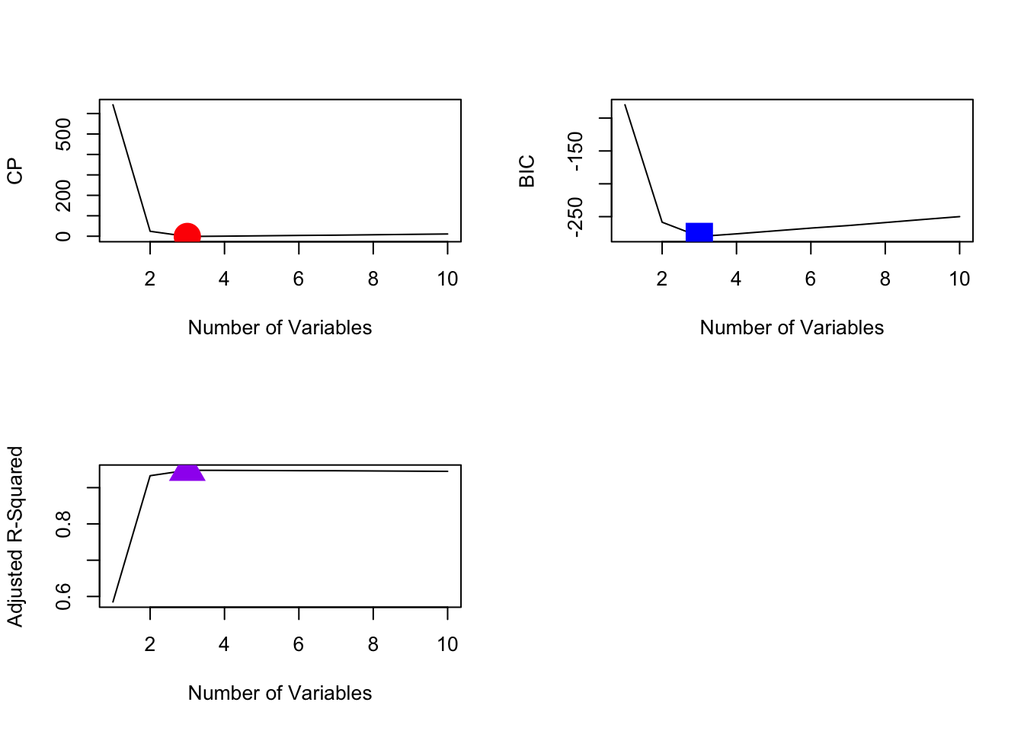

```r
par(mfrow=c(2,2))
## plot of cp
plot(regfit1.sum$cp,xlab='Number of Variables',ylab='CP',type="l")
points(which.min(regfit1.sum$cp),regfit1.sum$cp[which.min(regfit1.sum$cp)],col='red',cex=3,pch=16)
## plot of BIC
plot(regfit1.sum$bic,xlab='Number of Variables',ylab='BIC',type="l")
points(which.min(regfit1.sum$bic),regfit1.sum$bic[which.min(regfit1.sum$bic)],col='Blue',cex=3,pch=15)
## plot of Adjusted R-squared
plot(regfit1.sum$adjr2,xlab='Number of Variables',ylab='Adjusted R-Squared',type="l")
points(which.max(regfit1.sum$adjr2),regfit1.sum$adjr2[which.max(regfit1.sum$adjr2)],col='Purple',cex=3,pch=17)

## We may notice that when the number of variables = 3, the CP and BIC is the smallest and Adjusted R-squared is the biggest. Therefore, the best model is when number of variables = 3.
```

```r
## Best model's coefficient
coef(regfit1,3)
```

```
## (Intercept)           x          x2          x7
##  3.07627412  2.35623596 -3.16514887  0.01046843
```

```
(d) Repeat (c), using forward stepwise selection and also using backwards stepwise selection. How does your answer compare to the results in (c)?
```

```r
regfit.back = regsubsets(y~.,data=full,nvmax=10,method='backward')
back1 = summary(regfit.back)
coef(regfit.back,3)
```

```
##  (Intercept)            x           x2           x9
##  3.078881355  2.419817953 -3.177235617  0.001870457
```

```r
regfit.for = regsubsets(y~.,data=full,nvmax=10,method='forward')
for1 = summary(regfit.for)
coef(regfit.for,3)
```

```
## (Intercept)           x          x2          x7
##  3.07627412  2.35623596 -3.16514887  0.01046843
```

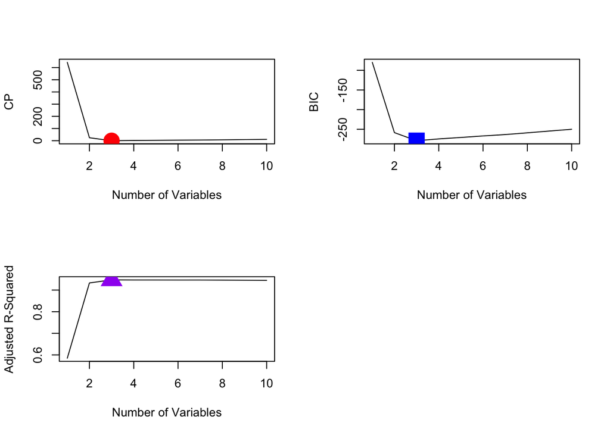

```r
# plot for backward selection
par(mfrow=c(2,2))
## plot of cp
plot(back1$cp,xlab='Number of Variables',ylab='CP',type="l")
points(which.min(back1$cp),back1$cp[which.min(back1$cp)],col='red',cex=3,pch=16)
## plot of BIC
plot(back1$bic,xlab='Number of Variables',ylab='BIC',type="l")
points(which.min(back1$bic),back1$bic[which.min(back1$bic)],col='Blue',cex=3,pch=15)
## plot of Adjusted R-squared
plot(back1$adjr2,xlab='Number of Variables',ylab='Adjusted R-Squared',type="l")
points(which.max(back1$adjr2),back1$adjr2[which.max(back1$adjr2)],col='Purple',cex=3,pch=17)
```

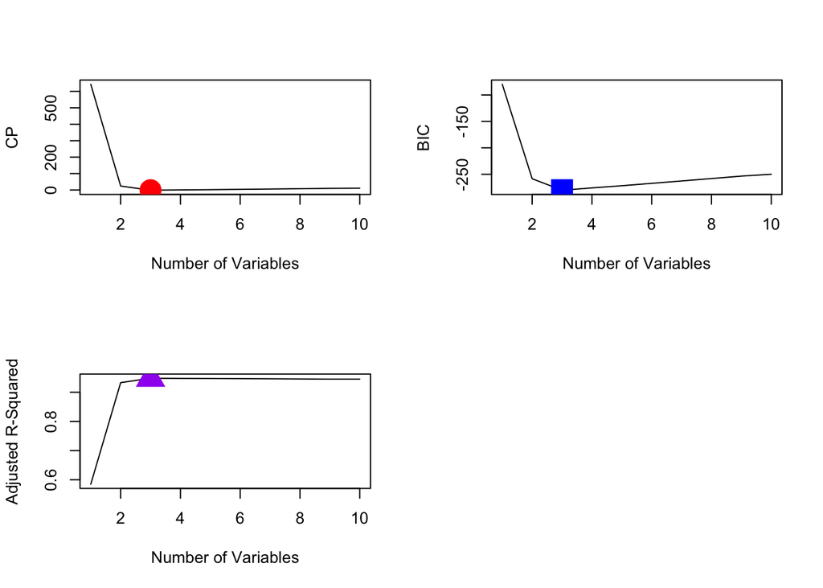

```r
#plot of forward selection
par(mfrow=c(2,2))
## plot of cp
plot(for1$cp,xlab='Number of Variables',ylab='CP',type="l")
points(which.min(for1$cp),for1$cp[which.min(for1$cp)],col='red',cex=3,pch=16)
## plot of BIC
plot(for1$bic,xlab='Number of Variables',ylab='BIC',type="l")
points(which.min(for1$bic),for1$bic[which.min(for1$bic)],col='Blue',cex=3,pch=15)
## plot of Adjusted R-squared
plot(for1$adjr2,xlab='Number of Variables',ylab='Adjusted R-Squared',type="l")
points(which.max(for1$adjr2),for1$adjr2[which.max(for1$adjr2)],col='Purple',cex=3,pch=17)
```

```r
# When using the backward forward selection, the number of true variables are all 3, which is equal to the best subset selection.
# While in best-subset-selection and forward-selection, the best variables are x1, x2, and x7. However, the best variables using backward selection are x1,x2 and x9.
```

[output not shown]

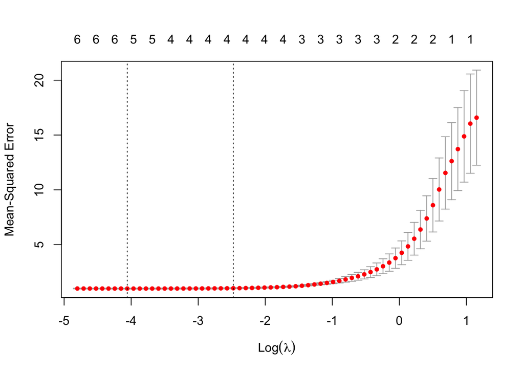

```r
#set x and y
y.l = as.matrix(full[,1])
x.l = as.matrix(full[,2:11])

#use glmnet to fit the lasso regression and use 5-fold cross-validation
cv.l <- cv.glmnet(x.l,y.l,alpha=1,nfolds=5)

# Plot the result
plot(cv.l)
```

```r
cat("Lambda with smallest CV Error", cv.l$lambda[which.min(cv.l$cvm)],fill=TRUE)
```

```
## Lambda with smallest CV Error 0.01727789
```

```r
cat("Coefficients", as.numeric(coef(cv.l)),fill=TRUE)
```

```
## Coefficients 3.00316 2.179634 -3.049368 0.01947017 0 0.04709426 0 0 0 0 0
```

```r
# After using lasso regression, we can get X, X^2, X^3, and X^5 as variables for this model.
```

```
(f) Now generate a response vector $Y$ according to the model $$Y = \beta_0 + \beta_7 X^7 + \epsilon,$$ where $\beta_7 = 7$, and perform best subset selection and the LASSO. Discuss the results obtained.
```

```r
b7 = 7
y2 = b0 + b7 * x^7 + epsilon
full2 = data.frame(y2=y2,x=x,x2=x^2,x3=x^3,x4=x^4,x5=x^5,x6=x^6,x7=x^7,x8=x^8,x9=x^9,x10=x^10)
```

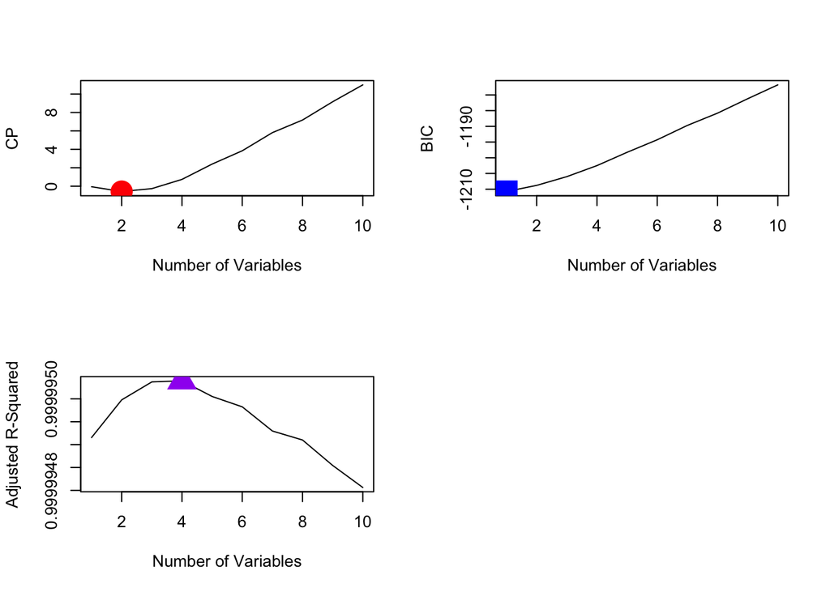

```r
#Best-subset-selection
regfit2 = regsubsets(y2 ~ .,data = full2,nvmax=10)
regfit2.sum=summary(regfit2)

# plot the best-subset-selection
par(mfrow=c(2,2))
## plot of cp
plot(regfit2.sum$cp,xlab='Number of Variables',ylab='CP',type="l")
points(which.min(regfit2.sum$cp),regfit2.sum$cp[which.min(regfit2.sum$cp)],col='red',cex=3,pch=16)
## plot of BIC
plot(regfit2.sum$bic,xlab='Number of Variables',ylab='BIC',type="l")
points(which.min(regfit2.sum$bic),regfit2.sum$bic[which.min(regfit2.sum$bic)],col='Blue',cex=3,pch=15)
## plot of Adjusted R-squared
plot(regfit2.sum$adjr2,xlab='Number of Variables',ylab='Adjusted R-Squared',type="l")
points(which.max(regfit2.sum$adjr2),regfit2.sum$adjr2[which.max(regfit2.sum$adjr2)],col='Purple',cex=3,pch=17)
```

```r
# When use cp to choose the best model,, the result is when number of variables are 2.

# When use BIC to choose the best model, the result is when number of variables are 1.

# When use Adjusted R_Squared to choose the best model, the result is when number of variables are 4.
```

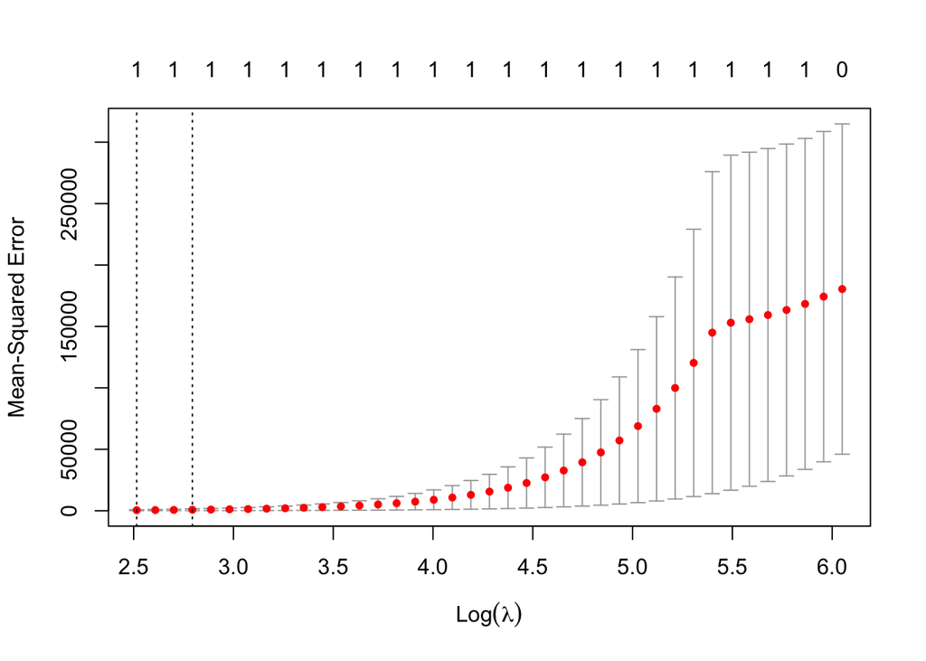

```r
#set x and y
y.l2 = as.matrix(full2[,1])
x.l2 = as.matrix(full2[,2:11])

#use glmnet to fit the lasso regression and use 5-fold cross-validation
cv.l2 <- cv.glmnet(x.l2,y.l2,alpha=1,nfolds=5)

# Plot the result
plot(cv.l2)
```